# An introduction to a priori power analysis through simulation

## Ladislas Nalborczyk

### LPL (CNRS) · Aix-Marseille Univ (currently visiting Duke University)

## Why should I care about statistical power?

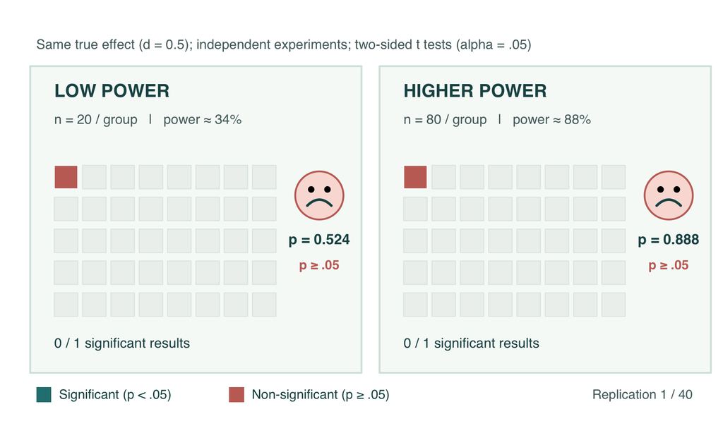

Even when a real effect exists, a **low-powered study is unlikely to detect it reliably**. A priori power analysis helps us plan a study with a sufficient probability of achieving its goal, under explicit assumptions.

# Why simulate statistical power?

## Power is a probability under an assumed model

In null-hypothesis significance testing (NHST), **statistical power** is the probability of rejecting the null hypothesis $\mathcal{H}_{0}$ when a specified alternative data-generating model $\mathcal{M}$ is true.

$$\operatorname{Power}(n, \theta)
= \Pr\!\left(\text{reject } \mathcal{H}_{0} \mid n, \theta, \mathcal{M}\right).$$

False positive rate (Type I error): $\Pr(\text{reject }\mathcal{H}_0 \mid \mathcal{H}_0)$  
$\alpha$

True positive rate (Power): $\Pr(\text{reject }\mathcal{H}_0 \mid \mathcal{H}_1)$  
$1-\beta$

True negative rate: $\Pr(\text{fail to reject }\mathcal{H}_0 \mid \mathcal{H}_0)$  
$1-\alpha$

False negative rate (Type II error): $\Pr(\text{fail to reject }\mathcal{H}_0 \mid \mathcal{H}_1)$  
$\beta$

**Important:** Power is conditional on the assumed effect, variability, design, analysis, and decision rule. It is not the probability that your hypothesis is true.

## Power, in a broader sense

> Statistical power is the probability of attaining the goal of a planned empirical study, assuming a particular underlying state of the world.

> Adapted from Kruschke (2015), *Doing Bayesian Data Analysis*.

The **goal** need not be $p<.05$:

- Obtain $p<\alpha$ or a Bayes factor (BF) above a pre-specified threshold.
- Find a credible interval **entirely outside** a region of practical equivalence (ROPE).
- Find a credible interval **entirely inside** a ROPE.
- Achieve a pre-specified estimation precision (e.g., confidence/credible interval width).

## Why use simulation?

### Analytical calculations

- Fast and exact for many textbook designs.
- Convenient tools such as [G*Power](https://www.psychologie.hhu.de/arbeitsgruppen/allgemeine-psychologie-und-arbeitspsychologie/gpower).
- Less flexible when the design, statistical model, or success criterion changes.

### Simulation-based planning

- Model the actual data-collection process.
- Fit the intended analysis to synthetic datasets.
- Define **any computable success criterion** and explore realistic nuisance parameters.

Simulation does not replace statistical assumptions; it makes them **explicit and testable**.

## A general workflow

1. **Specify** the data-generating model, plausible parameters, and sample sizes.
2. **Generate** one synthetic dataset.
3. **Analyse** it using the planned statistical model.
4. **Classify** the result according to the pre-specified goal.
5. **Repeat** and estimate the proportion of successful studies.

$$\widehat{\operatorname{Power}}(n,\theta)
=\frac{1}{R}\sum_{r=1}^{R}\mathbf{I}\{\text{goal attained in simulation }r\}.$$

## Define the target before simulating

| Question | Example for a two-sample experiment |
| --- | --- |
| Data-generating model | Independent normal observations, equal variance |
| Design variable | $n$ participants **per group** |
| Assumed effect | Standardised mean difference $d=0.5$ |
| Analysis | Two-sided, equal-variance $t$ test |
| Decision criterion | $p<.05$ |
| Target success probability | At least 80% |

A sample size is only meaningful **relative to a particular set of assumptions and goals**.

# Example 1 · Significance testing

## Step 1 · Simulate one experiment

For two independent groups, let $X\sim\mathcal N(0,1)$ and $Y\sim\mathcal N(d,1)$.

```r
simulate_p <- function (n, d) {

    # we could also use rlnorm for simulating RTs, rbinom for accuracies, etc
    x <- rnorm(n, mean = 0, sd = 1)
    y <- rnorm(n, mean = d, sd = 1)

    t_results <- t.test(y, x, var.equal = TRUE)

    return (t_results$p.value)

}
```

Here, **`n` is the number of participants per group** and `d` is the population mean difference in standard-deviation units.

```r
simulate_p(n = 36, d = 0.5)
```

```
[1] 0.003012015
```

One simulated $p$-value is one possible outcome, not an estimate of power.

## Step 2 · Repeat the experiment

```r
R <- 1e4
p_values <- replicate(n = R, expr = simulate_p(n = 36, d = 0.5) )
power_hat <- mean(p_values < 0.05)
mc_se <- sqrt(power_hat * (1 - power_hat) / R)

round(x = c(estimated_power = power_hat, MC_SE = mc_se), digits = 3)
```

```
estimated_power           MC_SE
          0.548           0.005
```

$$\widehat{\operatorname{Power}} =
\frac{\#\{p_r<.05\}}{R}$$

Note: The Monte Carlo standard error quantifies **numerical uncertainty in the simulation estimate**, not uncertainty about the assumed population effect.

## Sanity check · Compare with analytical power

This simple design also has an analytical benchmark. A simulation implementation should reproduce it to within **Monte Carlo error**.

```r
analytical_power <- power.t.test(
  n = 36, delta = 0.5, sd = 1, sig.level = 0.05,
  type = "two.sample", alternative = "two.sided"
  )$power

round(x = c(simulated = power_hat, analytical = analytical_power), digits = 3)
```

```
 simulated analytical
     0.548      0.553
```

Use analytical solutions or small, independently checked special cases to **validate a new simulation function** before applying it to more complex designs.

## The distribution of simulated $p$-values

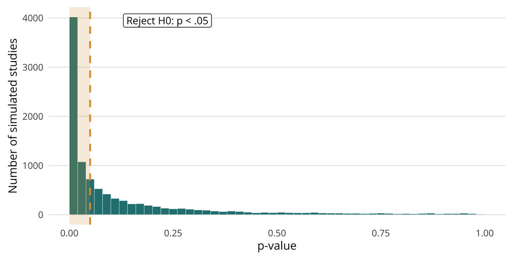

## The distribution of simulated $p$-values

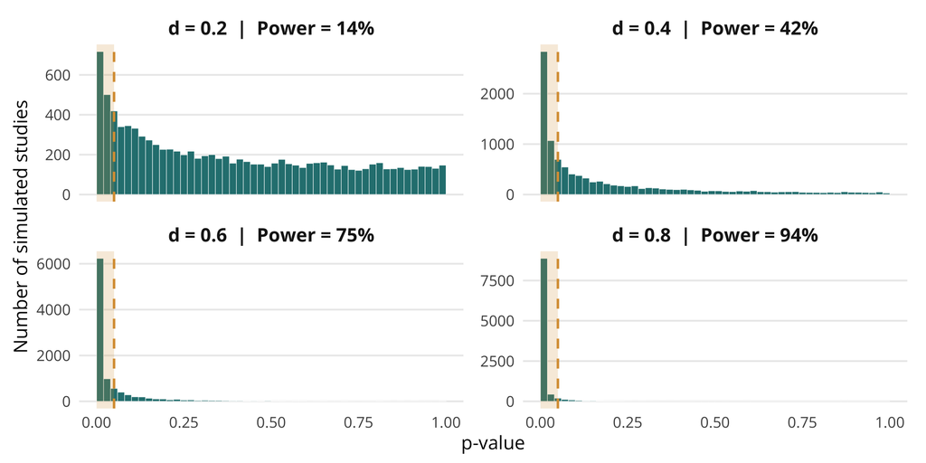

## Step 3 · Explore plausible sample sizes and effects

Generating every individual observation is intuitive, but a **vectorised equivalent** is faster for this specific model. Under equal variances, the test statistic follows a noncentral $t$ distribution:

$$T\sim t_{2n-2}\!\left(\delta=d\sqrt{n/2}\right).$$

```r
simulate_power_fast <- function (n, d, reps = 1e4, alpha = 0.05) {

    df <- 2 * n - 2
    t_draws <- rt(reps, df = df, ncp = d * sqrt(n / 2) )
    p <- 2 * pt(-abs(t_draws), df = df)

    return (mean(p < alpha) )

    }

power_grid <- expand.grid(
    n = seq(from = 20, to = 200, by = 20),
    d = seq(from = 0.1, to = 1, by = 0.1)
    )

power_grid$power <- mapply(
    simulate_power_fast, power_grid$n, power_grid$d,
    MoreArgs = list(reps = 1e4)
    )
```

## The simulated power surface

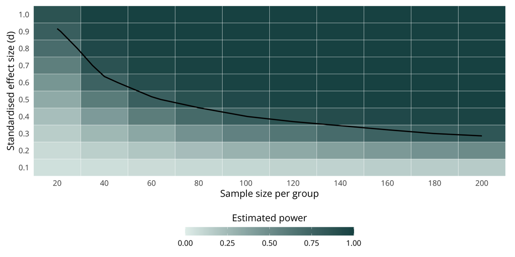

Dark contour: approximately 80% power. Each cell is estimated from 10,000 simulated test statistics.

## A different view: power curves

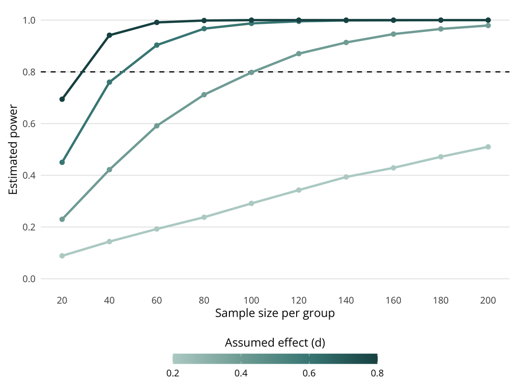

Rather than selecting one optimistic effect size, examine a **range of scientifically plausible effects**.

## How many simulation repetitions?

For $R$ approximately independent simulated studies, the Monte Carlo standard error is

$$\mathrm{MCSE}\left(\widehat{p}\right)
\approx \sqrt{\frac{\widehat{p}(1-\widehat{p})}{R}}.$$

When the estimated success probability is $0.80$:

| Number of simulations | MC standard error | Approximate 95% MC margin |
| --- | --- | --- |
| 1,000 | 0.013 | ±0.025 |
| 4,000 | 0.006 | ±0.012 |
| 10,000 | 0.004 | ±0.008 |

Increase $R$ until the Monte Carlo error is small **relative to the planning decision**. Report $R$, assumptions, and the simulation seed.

# Example 2 · A Bayesian decision rule

## What if success is not “significant”?

The **region of practical equivalence (ROPE)** is a prespecified range of effects small enough to be considered practically negligible (see [Kruschke, 2018](https://doi.org/10.1177/2515245918771304)). Here, ROPE boundaries are −0.1 and +0.1.

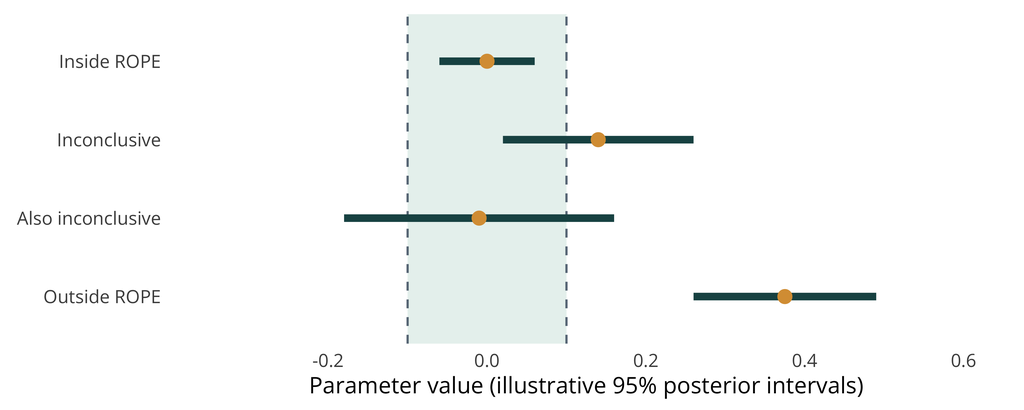

## Three outcomes, not a single “success” category

### Inside

The entire interval lies **inside** the ROPE.

Supports practical equivalence.

### Outside

The entire interval lies **outside** the ROPE, on either side.

Supports a non-negligible effect.

### Overlapping

The interval overlaps a ROPE boundary or spans the ROPE.

Inconclusive by this rule.

**Decide what counts as success beforehand.** Power to find practical equivalence and power to exclude practical equivalence are *different* quantities.

## Example: a $2\times2$ between-subject design

Let the parameter of interest be the interaction $\beta_{12}$.

$$\begin{aligned}
y_i &\sim \mathcal N(\mu_i,\sigma^2), \\
\mu_i &= \alpha+\beta_1 x_{1i}+\beta_2 x_{2i}
+\beta_{12}x_{1i}x_{2i}.
\end{aligned}$$

**Illustrative assumptions**

- $n$ = **total** sample size, balanced across four cells.
- $\alpha=10$, $\beta_1=0.3$, $\beta_2=-0.5$, $\sigma=1$.
- Explore $\beta_{12}\in\{0,0.15,1.1\}$.

## Generate the factorial datasets

```r
simulate_factorial <- function (n, beta12, sigma = 1) {

    stopifnot(n %% 4 == 0)
    design <- expand.grid(x1 = c(0, 1), x2 = c(0, 1) )
    design <- design[rep(seq_len(nrow(design)), each = n / 4), ]
    mu <- 10 + 0.3 * design$x1 - 0.5 * design$x2 +
    beta12 * design$x1 * design$x2
    design$y <- rnorm(n, mean = mu, sd = sigma)

    return (design)

    }
```

```r
example_data <- simulate_factorial(n = 80, beta12 = 1.1)
head(example_data, 4)
```

[output not shown]

Here, $n=80$ means **20 observations per cell**.

## Posterior inference, without a costly MCMC loop

For a transparent teaching example, assume $\sigma=1$ is **known** and use independent normal priors on the regression coefficients. With a normal likelihood, the posterior is available analytically.

```r
posterior_ci <- function (dat, sigma = 1) {

    X <- model.matrix(~ x1 * x2, data = dat)
    prior_mean <- c(10, 0, 0, 0)
    prior_prec <- diag(1 / c(25, 4, 4, 4)^2)
    post_cov <- solve(crossprod(X) / sigma^2 + prior_prec)
    post_mean <- post_cov %*% (
        crossprod(X, dat$y) / sigma^2 + prior_prec %*% prior_mean
        )
    k <- which(colnames(X) == "x1:x2")
    c(lower = as.numeric(post_mean[k] - 1.96 * sqrt(post_cov[k, k]) ),
    upper = as.numeric(post_mean[k] + 1.96 * sqrt(post_cov[k, k]) ) )

    }
```

Priors: intercept $\mathcal N(10,25^2)$; slopes $\mathcal N(0,4^2)$. The Gaussian 95% equal-tailed credible interval coincides with the 95% highest-density interval. For unknown $\sigma$ or hierarchical designs, fit the full Bayesian model instead.

## Classify each posterior interval

```r
classify_rope <- function (lower, upper, rope = c(-0.1, 0.1) ) {

    ifelse(
        lower >= rope[1] & upper <= rope[2], "Inside ROPE",
        ifelse(lower > rope[2] | upper < rope[1], "Outside ROPE", "Inconclusive")
        )

}
```

```r
c(
    illustrative_interval = posterior_ci(example_data),
    decision = classify_rope(posterior_ci(example_data)[1], posterior_ci(example_data)[2])
    )
```

```
illustrative_interval.lower illustrative_interval.upper
        "0.153932543957369"          "1.89080206564828"
             decision.lower
             "Outside ROPE"
```

**Important:** An interval that excludes zero need not lie outside the entire ROPE. The two criteria are not interchangeable.

## Repeat for alternative true effects and sample sizes

```r
reps <- 1e3 # 1,000 repetitions per cell

rope_results <- do.call(rbind, lapply(c(0, 0.15, 1.1), function (b) {
    do.call(rbind, lapply(seq(20, 200, by = 20), function (n) {
        intervals <- replicate(reps, posterior_ci(simulate_factorial(n, b) ) )
        data.frame(n = n, true_beta12 = b, lower = intervals[1, ], upper = intervals[2, ])
        }))
    }))

rope_results$decision <- classify_rope(rope_results$lower, rope_results$upper)
```

The code above simulates **three distinct underlying effects**. Each may produce different probabilities of equivalence, non-equivalence and an inconclusive result.

## What does the decision procedure achieve?

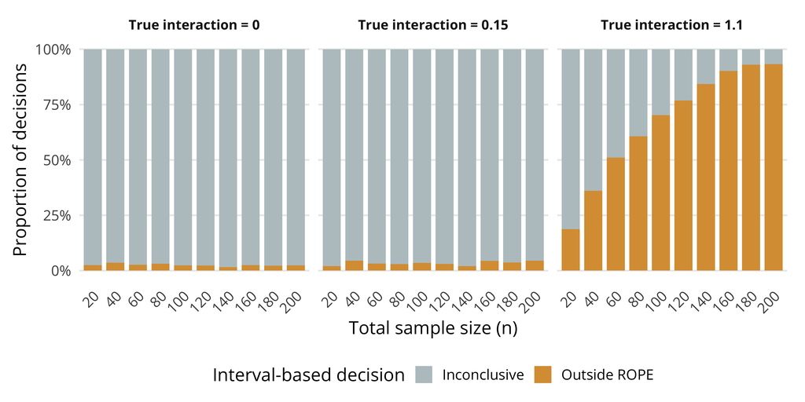

## Interpreting these results

- When the true interaction is **large** relative to the ROPE, increasing $n$ usually improves the chance of finding an interval wholly **outside** the ROPE.
- Near the ROPE, many intervals will remain **inconclusive**, even at moderate sample sizes.
- Demonstrating an effect is **practically equivalent to zero** can require much more precision than merely rejecting an exact-zero null.

A Bayesian success probability depends on the **prior, likelihood, decision criterion, assumed true parameters, and sample size**.

# Example 3 · Planning for precision

## What if the aim is to get a useful estimate?

Instead of choosing $n$ to exceed a significance threshold, choose $n$ such that an uncertainty interval is **narrow enough to answer the scientific question**.

For example:

- Define the smallest effect size of interest (SESOI) or a ROPE.
- Specify the desired **confidence/credible interval width**.
- Choose a sample size that achieves this width with sufficiently high probability.

## Example: precision of a correlation estimate

For a correlation of $\rho=0.30$, the Fisher-$z$ approximation gives an illustrative interval width as $n$ grows. Analytical illustration using Fisher’s transform; the assumed population correlation is 0.30 (see also [Schönbrodt & Perugini, 2013](https://doi.org/10.1016/j.jrp.2013.05.009)).

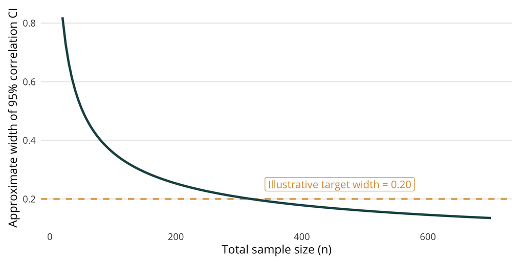

## A reproducible reporting check-list

1. **Scientific goal:** effect detection, practical equivalence, or estimation precision?
2. **Model:** complete data-generating process and assumptions.
3. **Analysis:** exact estimator/model intended for the real data.
4. **Criterion:** explicit formula for declaring a successful study.
5. **Grid:** sample sizes and plausible parameter settings explored.
6. **Simulation quality:** repetitions, Monte Carlo error, seed, code and diagnostics.

A trustworthy simulation-based power analysis is a **small, reproducible study about a planned study**.

# Conclusions

## Take-home messages

1. Power is **conditional** on a model, an effect, and a success criterion.
2. Simulation generalises sample-size planning to complex designs and non-NHST goals.
3. **Generate → analyse → classify → repeat** is the core algorithm.
4. Keep **evidence for equivalence** separate from **evidence against equivalence**.
5. Plan for **precision and robustness**, not merely a conventional threshold.

## Further resources

- [Kruschke (2015), *Doing Bayesian Data Analysis*](https://sites.google.com/site/doingbayesiandataanalysis/), especially the simulation-based planning chapter.
- [Kruschke (2018), *Rejecting or Accepting Parameter Values in Bayesian Estimation*](https://doi.org/10.1177/2515245918771304).
- [Schönbrodt & Perugini (2013), *At what sample size do correlations stabilize?*](https://doi.org/10.1016/j.jrp.2013.05.009)
- [Rothman & Greenland (2018), Planning study size based on precision rather than power](https://journals.lww.com/epidem/Fulltext/2018/09000/Planning_Study_Size_Based_on_Precision_Rather_Than.1.aspx).
- [The `precisely` R package](https://github.com/malcolmbarrett/precisely) and its [Shiny application](https://malcolmbarrett.shinyapps.io/precisely/).
- [Lakens, *Improving Your Statistical Inferences*](https://lakens.github.io/statistical_inferences/), especially the “Sample Size Justification” chapter.
- [Schönbrodt et al. (2017), Sequential hypothesis testing with Bayes factors: Efficiently testing mean differences](https://doi.org/10.1037/met0000061).
- [Beffara Bret, Beffara Bret, & Nalborczyk, L. (2021), A fully automated, transparent, reproducible, and blind protocol for sequential analyses](https://doi.org/10.15626/MP.2018.869).

## Thank you!

### Find me online

[GitHub](https://github.com/lnalborczyk)

[Bluesky](https://bsky.app/profile/lnalborczyk.bsky.social)

[Personal website](https://lnalborczyk.github.io)

### Slides and code

[figure not shown]